# Parasitological Analysis

## Analysis Overview

##### Data source: NSF-Senegal project,

- Baseline & Midline CRDES survey data
- Baseline & Midline EPLS & UCAD parasitological data
- Baseline & Midline Notre Dame Ecological Data

This analysis proceeds in **two steps** for each of the primary outcome variables of interest:

1. **Lasso-Logit Regression**  
   We first use Lasso regression to identify the most predictive covariates for each outcome. This helps reduce dimensionality and guard against overfitting.
2. **Evaluation using Confusion Matrices**  
   We apply the fitted model to the test data and generate confusion matrices to assess predictive performance, including metrics such as sensitivity, specificity, and overall accuracy.

## Outcome Variables

- **`sm_sh_inf`: Joint-Infection indicator**  
  Equals 1 if either `sh_inf` or `sm_inf` is equal to 1.  
  *Captures cases of either or both infections.*

**Training testing data**

Here we create Training and Testing data to perform prediction by subsetting 70% of the data as training observations, and 30% as testing.

```r
# reproducibility
set.seed(20240611)

# make matrix sith total number of observations
n <- nrow(analysis_df)

# create a vector of shuffled row indices
shuffled_indices <- sample(n)

# compute the number of training observations (70%)
train_size <- floor(0.7 * n)

# indices for training and testing
train_indices <- shuffled_indices[1:train_size]
test_indices <- shuffled_indices[(train_size + 1):n]

# now subset the dataframes
train_df <- analysis_df[train_indices, ]
test_df <- analysis_df[test_indices, ]


# check the sizes
cat("Training set size:", nrow(train_df), "\n")
```

```
Training set size: 240
```

```r
cat("Testing set size:", nrow(test_df), "\n")
```

```
Testing set size: 104
```

**Summary Stats**

```r
summary_stats <- function(data, exclude = NULL) {
  # Remove excluded columns
  if (!is.null(exclude)) {
    data <- data[ , !(names(data) %in% exclude)]
  }

  # Keep only numeric columns
  data_numeric <- data[ , sapply(data, is.numeric)]

  # Remove columns where all values are NA
  data_numeric <- data_numeric[ , colSums(!is.na(data_numeric)) > 0, drop = FALSE]

  # Extract variable labels (if present)
  labels <- sapply(data_numeric, function(x) attr(x, "label"))

 # Compute summary statistics
  summary_df <- data.frame(
    Question = labels,
    Variable = names(data_numeric),
    N = sapply(data_numeric, function(x) sum(!is.na(x))),
    Min = round(sapply(data_numeric, function(x) min(x, na.rm = TRUE)), 2),
    Mean = round(sapply(data_numeric, function(x) mean(x, na.rm = TRUE)), 2),
    Max = round(sapply(data_numeric, function(x) max(x, na.rm = TRUE)), 2),
    SD = round(sapply(data_numeric, function(x) sd(x, na.rm = TRUE)), 2),
    row.names = NULL,
    stringsAsFactors = FALSE
  )

  return(summary_df)
}
```

Summary stats for the analysis data. I imputed per PAP, dropped p2_avg and rows with missings, and used winsorized/standardized versions of q_51, asset_index, and hh_10_.

```r
# add section and source labels based on variable ranges
## this is done dynamically so I don't have to replace the header or Source variable if we add new variables to the section.

paras_sum_stats_ad <- paras_sum_stats_ad %>%
  mutate(
    section = case_when(
      Variable %in% Variable[match("hh_age_", Variable):match("total_egg", Variable)] ~ "Individual-level Variables",
      Variable %in% Variable[match("living_01_bin", Variable):match("asset_index_std", Variable)] ~ "Household-level Variables",
      Variable %in% Variable[match("q_51_w99", Variable):match("InfectedBiomphalaria", Variable)] ~ "Community-level Variables",
      TRUE ~ "Other"
    ),
    Source = case_when(
      Variable %in% c("age_hp", "sex_hp") ~ "EPLS/UCAD Parasitological Data",  # <- Specific override
      Variable %in% Variable[match("hh_age_", Variable):match("health_5_9_", Variable)] ~ "CRDES Household Survey",
        Variable %in% Variable[match("living_01_bin", Variable):match("asset_index_std", Variable)] ~ "CRDES Household Survey",
      Variable == "q_51" | Variable == "q_51_w99" ~ "CRDES Community Survey",
      Variable %in% Variable[match("sh_inf", Variable):match("total_egg", Variable)] ~ "EPLS/UCAD Parasitological Data",
      Variable %in% Variable[match("schisto_indicator", Variable):match("InfectedBiomphalaria", Variable)] ~ "Notre Dame Ecological Data",
      TRUE ~ NA_character_
    ),
    row_id = row_number()
  )


# Prepare the base table
kbl_base <- paras_sum_stats_ad %>%
  select(-section, -row_id) %>%
  kbl(format = "html", caption = "Summary Statistics for Analysis Data, Baseline & Midline")

# Add group_rows dynamically by section
for (sec in unique(paras_sum_stats_ad$section)) {
  rows <- paras_sum_stats_ad %>% filter(section == sec) %>% pull(row_id)
  kbl_base <- kbl_base %>% group_rows(sec, min(rows), max(rows))
}

# Add styling, scrolling, and footnote
kbl_base %>%
  kable_styling(
    bootstrap_options = c("striped", "hover", "condensed", "responsive"),
    full_width = FALSE,
    position = "left"
  ) %>%
  scroll_box(width = "100%", height = "600px") %>%  # enables scrolling
  footnote(general = "Note: Baseline: 183 observations, Midline: 161 observations. Means are calculated from non-missing values.")
```

Summary Statistics for Analysis Data, Baseline & Midline

| Question | Variable | N | Min | Mean | Max | SD | Source |
| --- | --- | --- | --- | --- | --- | --- | --- |
| **Individual-level Variables** |  |  |  |  |  |  |  |
| Individual's age (years) | hh_age_ | 344 | 3.00 | 8.78 | 14.00 | 1.99 | CRDES Household Survey |
| EPLS/UCAD child age (years) | age_hp | 344 | 5.00 | 8.28 | 14.00 | 1.62 | EPLS/UCAD Parasitological Data |
| Individual's gender (1=Male, 0=Female) | hh_gender_ | 344 | 0.00 | 0.45 | 1.00 | 0.50 | CRDES Household Survey |
| EPLS/UCAD child sex (1=M, 0=F) | sex_hp | 344 | 0.00 | 0.44 | 1.00 | 0.50 | EPLS/UCAD Parasitological Data |
| Hours per week spent within 1 meter of surface water source, Winsorized 99th | hh_10_w99 | 344 | 0.00 | 3.54 | 25.00 | 5.06 | CRDES Household Survey |
| Harvest aquatic vegetation (1=Yes, 0=No) | hh_12_6_ | 344 | 0.00 | 0.00 | 1.00 | 0.05 | CRDES Household Survey |
| Currently enrolled in formal school? (1=Yes, 0=No) | hh_26_ | 344 | 0.00 | 0.86 | 1.00 | 0.34 | CRDES Household Survey |
| Attends school during the 2023/2024 academic year (1=Yes, 0=No) | hh_32_ | 344 | 0.00 | 0.86 | 1.00 | 0.35 | CRDES Household Survey |
| Missed >1 week of school due to illness, past 12mo (children only) | hh_37_ | 344 | 0.00 | 0.21 | 1.00 | 0.41 | CRDES Household Survey |
| Fell ill in the last 12 months (1=Yes, 0=No) | health_5_2_ | 344 | 0.00 | 0.58 | 1.00 | 0.49 | CRDES Household Survey |
| Suffered from Malaria (1=Yes, 0=No) | health_5_3_1_ | 344 | 0.00 | 0.17 | 1.00 | 0.38 | CRDES Household Survey |
| Suffered from Bilharzia (1=Yes, 0=No) | health_5_3_2_ | 344 | 0.00 | 0.26 | 1.00 | 0.44 | CRDES Household Survey |
| Suffered from Diarrhea (1=Yes, 0=No) | health_5_3_3_ | 344 | 0.00 | 0.02 | 1.00 | 0.13 | CRDES Household Survey |
| Suffered from Skin issues (1=Yes, 0=No) | health_5_3_6_ | 344 | 0.00 | 0.01 | 1.00 | 0.08 | CRDES Household Survey |
| Suffered from Stomach ache (1=Yes, 0=No) | health_5_3_9_ | 344 | 0.00 | 0.05 | 1.00 | 0.21 | CRDES Household Survey |
| Received medication for schistosomiasis past 12mo (1=Yes, 0=No) | health_5_5_ | 344 | 0.00 | 0.70 | 1.00 | 0.46 | CRDES Household Survey |
| Had blood in urine in the last 12 months (1=Yes, 0=No) | health_5_8_ | 344 | 0.00 | 0.29 | 1.00 | 0.46 | CRDES Household Survey |
| Had blood in stool in the last 12 months (1=Yes, 0=No) | health_5_9_ | 344 | 0.00 | 0.23 | 1.00 | 0.42 | CRDES Household Survey |
| Indicator for Schistosoma haematobium infection (1=Yes, 0=No) | sh_inf | 344 | 0.00 | 0.53 | 1.00 | 0.50 | EPLS/UCAD Parasitological Data |
| Indicator for Schistosoma mansoni infection (1=Yes, 0=No) | sm_inf | 344 | 0.00 | 0.24 | 1.00 | 0.43 | EPLS/UCAD Parasitological Data |
| Indicator for Schistosoma manson OR haematobium infection (1=Yes, 0=No) | sm_sh_inf | 344 | 0.00 | 0.62 | 1.00 | 0.48 | EPLS/UCAD Parasitological Data |
| Egg count for Schistosoma haematobium | sh_egg_count | 344 | 0.00 | 38.08 | 2120.00 | 176.64 | EPLS/UCAD Parasitological Data |
| Average EPG from P1 (Kato-Katz slide 1 and 2) | p1_avg | 344 | 0.00 | 32.54 | 2001.75 | 149.59 | EPLS/UCAD Parasitological Data |
| Egg count for Schistosoma mansoni | sm_egg_count | 344 | 0.00 | 36.41 | 2001.75 | 152.86 | EPLS/UCAD Parasitological Data |
| Total schistosome egg count | total_egg | 344 | 0.00 | 74.49 | 2152.00 | 235.04 | EPLS/UCAD Parasitological Data |
| **Household-level Variables** |  |  |  |  |  |  |  |
| Tap water as main source of drinking water (1=Yes, 0=No) | living_01_bin | 344 | 0.00 | 0.94 | 1.00 | 0.25 | CRDES Household Survey |
| Latrine in home (1=Yes, 0=No) | living_04_bin | 344 | 0.00 | 0.05 | 1.00 | 0.21 | CRDES Household Survey |
| Prob. self gets bilharzia in next 12mo (1=Agree/Strongly agree) | beliefs_01_bin | 344 | 0.00 | 0.57 | 1.00 | 0.50 | CRDES Household Survey |
| Prob. HH member gets bilharzia in next 12mo (1=Agree/Strongly agree) | beliefs_02_bin | 344 | 0.00 | 0.65 | 1.00 | 0.48 | CRDES Household Survey |
| Prob. child gets bilharzia in next 12mo (1=Agree/Strongly agree) | beliefs_03_bin | 344 | 0.00 | 0.79 | 1.00 | 0.41 | CRDES Household Survey |
| Standardized PCA Asset index | asset_index_std | 344 | -1.81 | 0.04 | 4.88 | 1.03 | CRDES Household Survey |
| **Community-level Variables** |  |  |  |  |  |  |  |
| Distance to health facility, Winsorized 99th | q_51_w99 | 344 | 0.00 | 6.97 | 40.00 | 10.58 | CRDES Community Survey |
| Ecological Schistosomiasis Infection Indicator (1=Yes, 0=No) | schisto_indicator | 344 | 0.00 | 0.33 | 1.00 | 0.47 | Notre Dame Ecological Data |
| Ceratophyllum Mass (g) | Cerratophyllummassg | 344 | 0.00 | 1343.98 | 7028.00 | 1689.28 | Notre Dame Ecological Data |
| Bulinus Snail (Count) | Bulinus | 344 | 0.00 | 78.16 | 834.00 | 151.13 | Notre Dame Ecological Data |
| Biomphalaria Snail (Count) | Biomph | 344 | 0.00 | 6.31 | 79.00 | 15.57 | Notre Dame Ecological Data |
| Human Water Contact (Count) | Humanwatercontact | 344 | 0.00 | 5.19 | 31.00 | 4.89 | Notre Dame Ecological Data |
| Infected Bulinus (Count) | InfectedBulinus | 344 | 0.00 | 0.62 | 4.00 | 1.13 | Notre Dame Ecological Data |
| Infected Biomphalaria (Count) | InfectedBiomphalaria | 344 | 0.00 | 0.15 | 3.00 | 0.60 | Notre Dame Ecological Data |

Note:  
Note: Baseline: 183 observations, Midline: 161 observations. Means are calculated from non-missing values.

**sm_sh_inf Analysis**

**Model specification**

This code runs a Lasso logistic regression with cross-validation to select key predictors of sm_sh_inf. It identifies the optimal lambda, fits the model, and extracts the non-zero (important) variables.

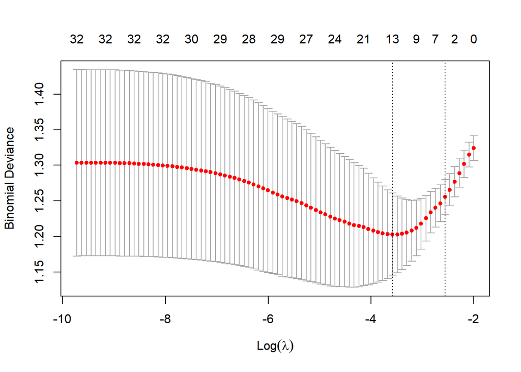

```r
exclude_vars <- c("hhid_village", "village_name", "hhid", "individ",
                  "identificant", "match_score", "round", "sh_inf", "sm_sh_inf", "sm_inf", "sh_egg_count","p1_avg", "sm_egg_count", "total_egg")  # Exclude outcome too

# Grab all other column names
  covariates <- setdiff(names(train_df), exclude_vars)

  # Create predictor matrix
  x <- data.matrix(train_df[, covariates])
  y <- train_df$sm_sh_inf

#perform k-fold cross-validation to find optimal lambda value
  k_val <- cv.glmnet(x, y, family = "binomial", alpha = 1)

    best_lambda <- k_val$lambda.min

#produce plot of test MSE by lambda value
    plot(k_val)
```

```r
#find coefficients of best model
model <- glmnet(x, y, alpha = 1, lambda = best_lambda, family = "binomial")

#model <- glmnet(x, y, alpha = 1, lambda = best_lambda)
  coef(model)
```

```
33 x 1 sparse Matrix of class "dgCMatrix"
                                s0
(Intercept)          -0.6730210115
hh_age_               .
hh_gender_            0.1320195854
hh_10_w99             .
hh_12_6_             -0.3532084333
hh_26_                .
hh_32_                .
hh_37_                .
health_5_2_           0.1069286065
health_5_3_1_         .
health_5_3_2_         .
health_5_3_3_        -2.3570526621
health_5_3_6_         .
health_5_3_9_         .
health_5_5_          -0.1782115675
health_5_8_           .
health_5_9_           0.6418533857
living_01_bin         .
living_04_bin         .
beliefs_01_bin        0.3150692444
beliefs_02_bin        .
beliefs_03_bin        .
asset_index_std       .
q_51_w99              .
schisto_indicator     0.4353011321
age_hp                0.0089315649
sex_hp                0.2032757908
Cerratophyllummassg   .
Bulinus               0.0006063762
Biomph                .
Humanwatercontact     0.0988530691
InfectedBulinus       .
InfectedBiomphalaria  0.2443070900
```

```r
#print regression table
  print(model)
```

```
Call:  glmnet(x = x, y = y, family = "binomial", alpha = 1, lambda = best_lambda)

  Df  %Dev  Lambda
1 13 17.28 0.02774
```

```r
# Extract coefficients at best lambda
  mat <- coef(model, s = best_lambda)

# Convert to named vector and find non-zero coefficients
  vars_raw <- rownames(mat)[mat[, 1] != 0]

# Remove intercept from selected vars
  vars <- setdiff(vars_raw, c("(Intercept)")) #confirm the precise variables we're interested in

  # kable(vars, format = "html", caption = "Best Predictors for Joint-Infection") %>%
  #     kable_styling(bootstrap_options = c("striped", "hover", "condensed", "responsive"), full_width = FALSE, position = "left") %>%
  #     scroll_box(width = "100%")
```

```r
# display best vars with labels

vars_raw <- rownames(mat)[mat[, 1] != 0]
vars <- setdiff(vars_raw, "(Intercept)")

# create a dataframe with variable names and their corresponding labels from train_df

var_labels <- tibble(
  variable = vars,
  label = sapply(vars, function(v) {
    if (v %in% names(train_df)) {
      var_label(train_df[[v]])
    } else {
      NA  # in case it's an interaction or transformed variable
    }
  })
)

var_labels <- var_labels %>%
  relocate(label, .before = variable)

# display with kable


kable(var_labels, format = "html", caption = "Best Predictors for Joint-Infection") %>%
  kable_styling(bootstrap_options = c("striped", "hover", "condensed", "responsive"), full_width = FALSE, position = "left") %>%
  scroll_box(width = "100%")
```

Best Predictors for Joint-Infection

| label | variable |
| --- | --- |
| Individual's gender (1=Male, 0=Female) | hh_gender_ |
| Harvest aquatic vegetation (1=Yes, 0=No) | hh_12_6_ |
| Fell ill in the last 12 months (1=Yes, 0=No) | health_5_2_ |
| Suffered from Diarrhea (1=Yes, 0=No) | health_5_3_3_ |
| Received medication for schistosomiasis past 12mo (1=Yes, 0=No) | health_5_5_ |
| Had blood in stool in the last 12 months (1=Yes, 0=No) | health_5_9_ |
| Prob. self gets bilharzia in next 12mo (1=Agree/Strongly agree) | beliefs_01_bin |
| Ecological Schistosomiasis Infection Indicator (1=Yes, 0=No) | schisto_indicator |
| EPLS/UCAD child age (years) | age_hp |
| EPLS/UCAD child sex (1=M, 0=F) | sex_hp |
| Bulinus Snail (Count) | Bulinus |
| Human Water Contact (Count) | Humanwatercontact |
| Infected Biomphalaria (Count) | InfectedBiomphalaria |

**Prediction - all**

The following output are the FPRs and FNRs using the logit-lasso coefficients. These are summarized in one confusion matrix.

```r
#get test data
x_test <- data.matrix(test_df[, covariates])  # only predictors

test_probs <- predict(model, newx = as.matrix(x_test), type = "response")

### Generalized to function

evaluate_thresholds <- function(test_probs, actual, thresholds = seq(0.1, 0.9, by = 0.1)) {
  results <- data.frame()

  for (threshold in thresholds) {
    pred_class <- ifelse(test_probs > threshold, 1, 0)

    TP <- sum(pred_class == 1 & actual == 1)
    TN <- sum(pred_class == 0 & actual == 0)
    FP <- sum(pred_class == 1 & actual == 0)
    FN <- sum(pred_class == 0 & actual == 1)

    FPR <- ifelse((FP + TN) > 0, FP / (FP + TN), NA)
    FNR <- ifelse((FN + TP) > 0, FN / (FN + TP), NA)
    Sum_FPR_FNR <- FPR + FNR

    results <- rbind(results, data.frame(
      Threshold = threshold,
      TP = TP, TN = TN, FP = FP, FN = FN,
      FPR = round(FPR, 3),
      FNR = round(FNR, 3),
      Sum_FPR_FNR = round(Sum_FPR_FNR, 3)
    ))
  }

  # Find threshold that minimizes FPR + FNR
  min_row <- results[which.min(results$Sum_FPR_FNR), ]
  attr(results, "best_threshold") <- min_row$Threshold

  return(results)
}

  results_df <- evaluate_thresholds(test_probs, test_df$sm_sh_inf)
#print(results_df)

# Best threshold (minimizing FPR + FNR)
  best_threshold <- attr(results_df, "best_threshold")

kable(results_df, format = "html", caption = "Confusion Matrix for sm_sh_inf at each threshold") %>%
  kable_styling(bootstrap_options = c("striped", "hover", "condensed", "responsive"), full_width = FALSE, position = "left") %>%
  scroll_box(width = "100%")
```

Confusion Matrix for sm_sh_inf at each threshold

| Threshold | TP | TN | FP | FN | FPR | FNR | Sum_FPR_FNR |
| --- | --- | --- | --- | --- | --- | --- | --- |
| 0.1 | 65 | 1 | 38 | 0 | 0.974 | 0.000 | 0.974 |
| 0.2 | 64 | 2 | 37 | 1 | 0.949 | 0.015 | 0.964 |
| 0.3 | 64 | 2 | 37 | 1 | 0.949 | 0.015 | 0.964 |
| 0.4 | 62 | 7 | 32 | 3 | 0.821 | 0.046 | 0.867 |
| 0.5 | 51 | 18 | 21 | 14 | 0.538 | 0.215 | 0.754 |
| 0.6 | 34 | 30 | 9 | 31 | 0.231 | 0.477 | 0.708 |
| 0.7 | 25 | 37 | 2 | 40 | 0.051 | 0.615 | 0.667 |
| 0.8 | 8 | 38 | 1 | 57 | 0.026 | 0.877 | 0.903 |
| 0.9 | 4 | 38 | 1 | 61 | 0.026 | 0.938 | 0.964 |

```r
kable(best_threshold, format = "html", caption = "Best Threshold") %>%
  kable_styling(bootstrap_options = c("striped", "hover", "condensed", "responsive"), full_width = FALSE, position = "left") %>%
  scroll_box(width = "100%")
```

Best Threshold

| x |
| --- |
| 0.7 |

##### Summarize and visualize the probababilities

This is a scatter plot of the predicted probability of infection against the egg count. Any dark red observations are the overlap of S. mansoni and S. haematobium.

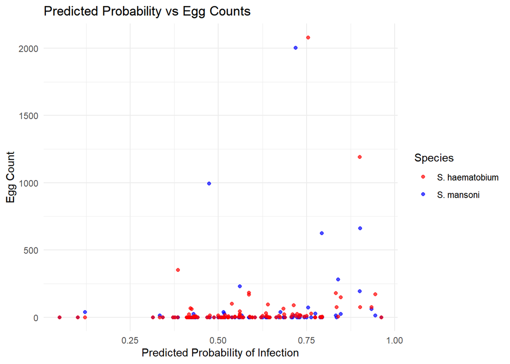

```r
### visulalize

# make a single df with that combines predictions and egg counts
plot_df <- data.frame(
  predicted_prob = test_probs,
  sm_egg_count = test_df$sm_egg_count,
  sh_egg_count = test_df$sh_egg_count
)

plot_df <- plot_df %>%
  rename(predicted_prob = s0)


# create scatter plot with color-coded species

 ggplot(plot_df) +
  geom_point(aes(x = predicted_prob, y = sm_egg_count, color = "S. mansoni"), alpha = 0.7) +
  geom_point(aes(x = predicted_prob, y = sh_egg_count, color = "S. haematobium"), alpha = 0.7) +
  scale_color_manual(values = c("S. mansoni" = "blue", "S. haematobium" = "red")) +
  labs(
    title = "Predicted Probability vs Egg Counts",
    x = "Predicted Probability of Infection",
    y = "Egg Count",
    color = "Species"
  ) +
  theme_minimal()
```

```r
### visulalize

test_probs_df <- summary(test_probs)

kable(test_probs_df, format = "html", caption = "Summary of Probabilities") %>%
  kable_styling(bootstrap_options = c("striped", "hover", "condensed", "responsive"), full_width = FALSE, position = "left") %>%
  scroll_box(width = "100%")
```

Summary of Probabilities

|  | s0 |
| --- | --- |
|  | Min. :0.05017 |
|  | 1st Qu.:0.44040 |
|  | Median :0.56118 |
|  | Mean :0.57838 |
|  | 3rd Qu.:0.70760 |
|  | Max. :0.96226 |

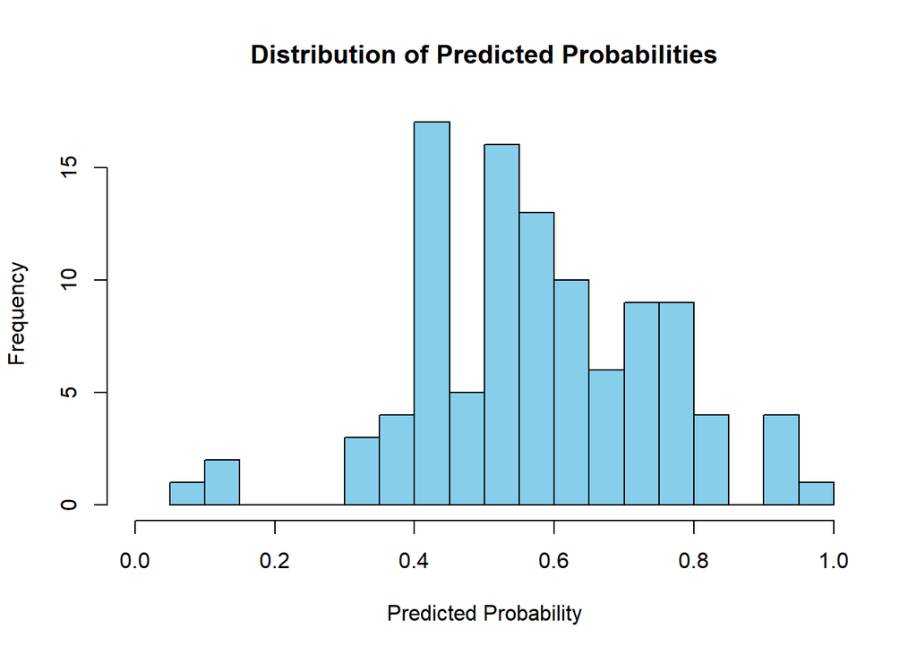

```r
#hist(test_probs, breaks = 20, col = "skyblue", main = "Distribution of Predicted Probabilities")

hist(test_probs,
     breaks = 20,
     col = "skyblue",
     main = "Distribution of Predicted Probabilities",
     xlab = "Predicted Probability",
     xlim = c(0, 1))
```